# Risk Factor Analysis

## Outcome Variable

**Outcome Variable:** haz

## Predictor Variables

**Intervention Variable:** vagbrth

**Adjustment Set:**

unadjusted

## Stratifying Variables

The analysis was stratified on these variable(s):

- agecat
- studyid
- country

## Data Summary

| agecat | studyid | country | vagbrth | n_cell | n |
| --- | --- | --- | --- | --- | --- |
| Birth | ki1000108-CMC-V-BCS-2002 | INDIA | 0 | 11 | 92 |
| Birth | ki1000108-CMC-V-BCS-2002 | INDIA | 1 | 81 | 92 |
| Birth | ki1000108-IRC | INDIA | 0 | 68 | 388 |
| Birth | ki1000108-IRC | INDIA | 1 | 320 | 388 |
| Birth | ki1017093b-PROVIDE | BANGLADESH | 0 | 108 | 539 |
| Birth | ki1017093b-PROVIDE | BANGLADESH | 1 | 431 | 539 |
| Birth | ki1017093c-NIH-Crypto | BANGLADESH | 0 | 186 | 477 |
| Birth | ki1017093c-NIH-Crypto | BANGLADESH | 1 | 291 | 477 |
| Birth | ki1119695-PROBIT | BELARUS | 0 | 1597 | 13890 |
| Birth | ki1119695-PROBIT | BELARUS | 1 | 12293 | 13890 |
| Birth | ki1126311-ZVITAMBO | ZIMBABWE | 0 | 1166 | 13761 |
| Birth | ki1126311-ZVITAMBO | ZIMBABWE | 1 | 12595 | 13761 |
| Birth | kiGH5241-JiVitA-3 | BANGLADESH | 0 | 539 | 22418 |
| Birth | kiGH5241-JiVitA-3 | BANGLADESH | 1 | 21879 | 22418 |
| Birth | kiGH5241-JiVitA-4 | BANGLADESH | 0 | 76 | 2822 |
| Birth | kiGH5241-JiVitA-4 | BANGLADESH | 1 | 2746 | 2822 |
| 6 months | ki1000108-CMC-V-BCS-2002 | INDIA | 0 | 25 | 369 |
| 6 months | ki1000108-CMC-V-BCS-2002 | INDIA | 1 | 344 | 369 |
| 6 months | ki1000108-IRC | INDIA | 0 | 69 | 407 |
| 6 months | ki1000108-IRC | INDIA | 1 | 338 | 407 |
| 6 months | ki1017093b-PROVIDE | BANGLADESH | 0 | 139 | 604 |
| 6 months | ki1017093b-PROVIDE | BANGLADESH | 1 | 465 | 604 |
| 6 months | ki1017093c-NIH-Crypto | BANGLADESH | 0 | 187 | 457 |
| 6 months | ki1017093c-NIH-Crypto | BANGLADESH | 1 | 270 | 457 |
| 6 months | ki1066203-TanzaniaChild2 | TANZANIA, UNITED REPUBLIC OF | 0 | 189 | 2005 |
| 6 months | ki1066203-TanzaniaChild2 | TANZANIA, UNITED REPUBLIC OF | 1 | 1816 | 2005 |
| 6 months | ki1119695-PROBIT | BELARUS | 0 | 1799 | 15761 |
| 6 months | ki1119695-PROBIT | BELARUS | 1 | 13962 | 15761 |
| 6 months | ki1126311-ZVITAMBO | ZIMBABWE | 0 | 740 | 8601 |
| 6 months | ki1126311-ZVITAMBO | ZIMBABWE | 1 | 7861 | 8601 |
| 6 months | kiGH5241-JiVitA-3 | BANGLADESH | 0 | 1077 | 16732 |
| 6 months | kiGH5241-JiVitA-3 | BANGLADESH | 1 | 15655 | 16732 |
| 6 months | kiGH5241-JiVitA-4 | BANGLADESH | 0 | 336 | 4052 |
| 6 months | kiGH5241-JiVitA-4 | BANGLADESH | 1 | 3716 | 4052 |
| 24 months | ki1000108-CMC-V-BCS-2002 | INDIA | 0 | 24 | 371 |
| 24 months | ki1000108-CMC-V-BCS-2002 | INDIA | 1 | 347 | 371 |
| 24 months | ki1000108-IRC | INDIA | 0 | 69 | 409 |
| 24 months | ki1000108-IRC | INDIA | 1 | 340 | 409 |
| 24 months | ki1017093b-PROVIDE | BANGLADESH | 0 | 137 | 578 |
| 24 months | ki1017093b-PROVIDE | BANGLADESH | 1 | 441 | 578 |
| 24 months | ki1017093c-NIH-Crypto | BANGLADESH | 0 | 99 | 260 |
| 24 months | ki1017093c-NIH-Crypto | BANGLADESH | 1 | 161 | 260 |
| 24 months | ki1066203-TanzaniaChild2 | TANZANIA, UNITED REPUBLIC OF | 0 | 2 | 6 |
| 24 months | ki1066203-TanzaniaChild2 | TANZANIA, UNITED REPUBLIC OF | 1 | 4 | 6 |
| 24 months | ki1119695-PROBIT | BELARUS | 0 | 472 | 4035 |
| 24 months | ki1119695-PROBIT | BELARUS | 1 | 3563 | 4035 |
| 24 months | ki1126311-ZVITAMBO | ZIMBABWE | 0 | 133 | 1619 |
| 24 months | ki1126311-ZVITAMBO | ZIMBABWE | 1 | 1486 | 1619 |
| 24 months | kiGH5241-JiVitA-3 | BANGLADESH | 0 | 480 | 8584 |
| 24 months | kiGH5241-JiVitA-3 | BANGLADESH | 1 | 8104 | 8584 |
| 24 months | kiGH5241-JiVitA-4 | BANGLADESH | 0 | 323 | 4020 |
| 24 months | kiGH5241-JiVitA-4 | BANGLADESH | 1 | 3697 | 4020 |

The following strata were considered:

- agecat: 24 months, studyid: ki1000108-CMC-V-BCS-2002, country: INDIA
- agecat: 24 months, studyid: ki1000108-IRC, country: INDIA
- agecat: 24 months, studyid: ki1017093b-PROVIDE, country: BANGLADESH
- agecat: 24 months, studyid: ki1017093c-NIH-Crypto, country: BANGLADESH
- agecat: 24 months, studyid: ki1066203-TanzaniaChild2, country: TANZANIA, UNITED REPUBLIC OF
- agecat: 24 months, studyid: ki1119695-PROBIT, country: BELARUS
- agecat: 24 months, studyid: ki1126311-ZVITAMBO, country: ZIMBABWE
- agecat: 24 months, studyid: kiGH5241-JiVitA-3, country: BANGLADESH
- agecat: 24 months, studyid: kiGH5241-JiVitA-4, country: BANGLADESH
- agecat: 6 months, studyid: ki1000108-CMC-V-BCS-2002, country: INDIA
- agecat: 6 months, studyid: ki1000108-IRC, country: INDIA
- agecat: 6 months, studyid: ki1017093b-PROVIDE, country: BANGLADESH
- agecat: 6 months, studyid: ki1017093c-NIH-Crypto, country: BANGLADESH
- agecat: 6 months, studyid: ki1066203-TanzaniaChild2, country: TANZANIA, UNITED REPUBLIC OF
- agecat: 6 months, studyid: ki1119695-PROBIT, country: BELARUS
- agecat: 6 months, studyid: ki1126311-ZVITAMBO, country: ZIMBABWE
- agecat: 6 months, studyid: kiGH5241-JiVitA-3, country: BANGLADESH
- agecat: 6 months, studyid: kiGH5241-JiVitA-4, country: BANGLADESH
- agecat: Birth, studyid: ki1000108-CMC-V-BCS-2002, country: INDIA
- agecat: Birth, studyid: ki1000108-IRC, country: INDIA
- agecat: Birth, studyid: ki1017093b-PROVIDE, country: BANGLADESH
- agecat: Birth, studyid: ki1017093c-NIH-Crypto, country: BANGLADESH
- agecat: Birth, studyid: ki1119695-PROBIT, country: BELARUS
- agecat: Birth, studyid: ki1126311-ZVITAMBO, country: ZIMBABWE
- agecat: Birth, studyid: kiGH5241-JiVitA-3, country: BANGLADESH
- agecat: Birth, studyid: kiGH5241-JiVitA-4, country: BANGLADESH

### Dropped Strata

Some strata were dropped due to rare outcomes:

- agecat: 24 months, studyid: ki1066203-TanzaniaChild2, country: TANZANIA, UNITED REPUBLIC OF

## Methods Detail

We’re interested in the causal parameters $E[Y_a]$ for all values of $a \in \mathcal{A}$. These parameters represent the mean outcome if, possibly contrary to fact, we intervened to set all units to have $A=a$. Under the randomization and positivity assumptions, these are identified by the statistical parameters $\psi_a=E_W[E_{Y|A,W}(Y|A=a,W)]$. In addition, we’re interested in the mean of $Y$, $E[Y]$ under no intervention (the observed mean). We will estimate these parameters by using SuperLearner to fit the relevant likelihood factors – $E_{Y|A,W}(Y|A=a,W)$ and $p(A=a|W)$, and then updating our likelihood fit using a joint TMLE.

For unadjusted analyses ($W=\{\}$), initial likelihoods were estimated using Lrnr_glm to estimate the simple $E(Y|A)$ and Lrnr_mean to estimate $p(A)$. For adjusted analyses, a small library containing Lrnr_glmnet, Lrnr_xgboost, and Lrnr_mean was used.

Having estimated these parameters, we will then use the delta method to estimate relative risks and attributable risks relative to a prespecified baseline level of $A$.

# Results Detail

## Results Plots

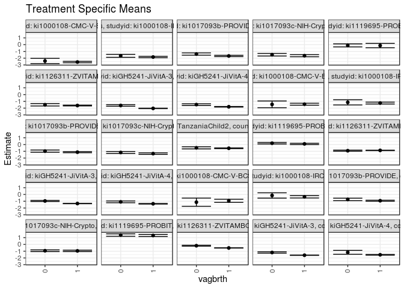

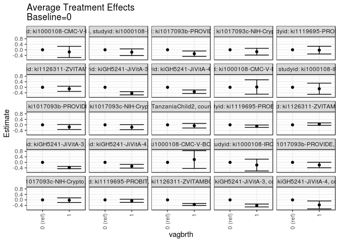

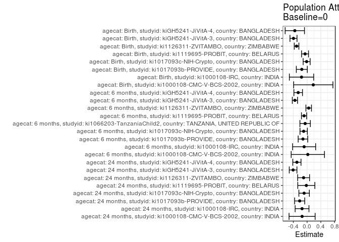

## Results Table

### Parameter: TSM

| agecat | studyid | country | intervention_level | baseline_level | estimate | ci_lower | ci_upper |
| --- | --- | --- | --- | --- | --- | --- | --- |
| Birth | ki1000108-CMC-V-BCS-2002 | INDIA | 0 | NA | -1.1418182 | -1.7488113 | -0.5348251 |
| Birth | ki1000108-CMC-V-BCS-2002 | INDIA | 1 | NA | -0.9366667 | -1.1678199 | -0.7055134 |
| Birth | ki1000108-IRC | INDIA | 0 | NA | -0.1467647 | -0.5389056 | 0.2453762 |
| Birth | ki1000108-IRC | INDIA | 1 | NA | -0.3423125 | -0.5182841 | -0.1663409 |
| Birth | ki1017093b-PROVIDE | BANGLADESH | 0 | NA | -0.7319444 | -0.9144312 | -0.5494576 |
| Birth | ki1017093b-PROVIDE | BANGLADESH | 1 | NA | -0.9234803 | -1.0050148 | -0.8419457 |
| Birth | ki1017093c-NIH-Crypto | BANGLADESH | 0 | NA | -0.9353763 | -1.0634434 | -0.8073093 |
| Birth | ki1017093c-NIH-Crypto | BANGLADESH | 1 | NA | -0.9560825 | -1.0629549 | -0.8492101 |
| Birth | ki1119695-PROBIT | BELARUS | 0 | NA | 1.3856512 | 1.2056669 | 1.5656356 |
| Birth | ki1119695-PROBIT | BELARUS | 1 | NA | 1.3193179 | 1.1587293 | 1.4799065 |
| Birth | ki1126311-ZVITAMBO | ZIMBABWE | 0 | NA | -0.1914666 | -0.2614539 | -0.1214792 |
| Birth | ki1126311-ZVITAMBO | ZIMBABWE | 1 | NA | -0.5253696 | -0.5468855 | -0.5038537 |
| Birth | kiGH5241-JiVitA-3 | BANGLADESH | 0 | NA | -1.1935065 | -1.2973967 | -1.0896163 |
| Birth | kiGH5241-JiVitA-3 | BANGLADESH | 1 | NA | -1.5989908 | -1.6183497 | -1.5796319 |
| Birth | kiGH5241-JiVitA-4 | BANGLADESH | 0 | NA | -1.1663158 | -1.4501885 | -0.8824430 |
| Birth | kiGH5241-JiVitA-4 | BANGLADESH | 1 | NA | -1.5330444 | -1.5829937 | -1.4830951 |
| 6 months | ki1000108-CMC-V-BCS-2002 | INDIA | 0 | NA | -1.4450667 | -1.9438291 | -0.9463042 |
| 6 months | ki1000108-CMC-V-BCS-2002 | INDIA | 1 | NA | -1.4218798 | -1.5688799 | -1.2748798 |
| 6 months | ki1000108-IRC | INDIA | 0 | NA | -1.1483575 | -1.5281894 | -0.7685255 |
| 6 months | ki1000108-IRC | INDIA | 1 | NA | -1.2519724 | -1.3898832 | -1.1140616 |
| 6 months | ki1017093b-PROVIDE | BANGLADESH | 0 | NA | -0.9716667 | -1.1320520 | -0.8112813 |
| 6 months | ki1017093b-PROVIDE | BANGLADESH | 1 | NA | -1.1275699 | -1.2112420 | -1.0438978 |
| 6 months | ki1017093c-NIH-Crypto | BANGLADESH | 0 | NA | -1.1741176 | -1.3139124 | -1.0343229 |
| 6 months | ki1017093c-NIH-Crypto | BANGLADESH | 1 | NA | -1.3417593 | -1.4576359 | -1.2258826 |
| 6 months | ki1066203-TanzaniaChild2 | TANZANIA, UNITED REPUBLIC OF | 0 | NA | -0.4889109 | -0.6482470 | -0.3295749 |
| 6 months | ki1066203-TanzaniaChild2 | TANZANIA, UNITED REPUBLIC OF | 1 | NA | -0.5514519 | -0.6033028 | -0.4996010 |
| 6 months | ki1119695-PROBIT | BELARUS | 0 | NA | 0.1945442 | 0.0853691 | 0.3037192 |
| 6 months | ki1119695-PROBIT | BELARUS | 1 | NA | 0.0957184 | -0.0008121 | 0.1922489 |
| 6 months | ki1126311-ZVITAMBO | ZIMBABWE | 0 | NA | -0.9157095 | -1.0000355 | -0.8313834 |
| 6 months | ki1126311-ZVITAMBO | ZIMBABWE | 1 | NA | -0.8641560 | -0.8911340 | -0.8371780 |
| 6 months | kiGH5241-JiVitA-3 | BANGLADESH | 0 | NA | -0.9595172 | -1.0399826 | -0.8790517 |
| 6 months | kiGH5241-JiVitA-3 | BANGLADESH | 1 | NA | -1.3377470 | -1.3608043 | -1.3146898 |
| 6 months | kiGH5241-JiVitA-4 | BANGLADESH | 0 | NA | -1.0916071 | -1.2218760 | -0.9613383 |
| 6 months | kiGH5241-JiVitA-4 | BANGLADESH | 1 | NA | -1.3734607 | -1.4172067 | -1.3297148 |
| 24 months | ki1000108-CMC-V-BCS-2002 | INDIA | 0 | NA | -2.4136111 | -2.8062260 | -2.0209962 |
| 24 months | ki1000108-CMC-V-BCS-2002 | INDIA | 1 | NA | -2.5689145 | -2.6716936 | -2.4661354 |
| 24 months | ki1000108-IRC | INDIA | 0 | NA | -1.6522222 | -1.8715963 | -1.4328481 |
| 24 months | ki1000108-IRC | INDIA | 1 | NA | -1.8285196 | -1.9316702 | -1.7253691 |
| 24 months | ki1017093b-PROVIDE | BANGLADESH | 0 | NA | -1.3868613 | -1.5544929 | -1.2192297 |
| 24 months | ki1017093b-PROVIDE | BANGLADESH | 1 | NA | -1.6693878 | -1.7645112 | -1.5742643 |
| 24 months | ki1017093c-NIH-Crypto | BANGLADESH | 0 | NA | -1.4916162 | -1.6808675 | -1.3023648 |
| 24 months | ki1017093c-NIH-Crypto | BANGLADESH | 1 | NA | -1.6305590 | -1.7873542 | -1.4737638 |
| 24 months | ki1119695-PROBIT | BELARUS | 0 | NA | -0.1093114 | -0.3338658 | 0.1152429 |
| 24 months | ki1119695-PROBIT | BELARUS | 1 | NA | -0.1343316 | -0.4544774 | 0.1858142 |
| 24 months | ki1126311-ZVITAMBO | ZIMBABWE | 0 | NA | -1.5032707 | -1.6823779 | -1.3241635 |
| 24 months | ki1126311-ZVITAMBO | ZIMBABWE | 1 | NA | -1.6133849 | -1.6737282 | -1.5530416 |
| 24 months | kiGH5241-JiVitA-3 | BANGLADESH | 0 | NA | -1.6076458 | -1.7248026 | -1.4904891 |
| 24 months | kiGH5241-JiVitA-3 | BANGLADESH | 1 | NA | -2.0385180 | -2.0658568 | -2.0111793 |
| 24 months | kiGH5241-JiVitA-4 | BANGLADESH | 0 | NA | -1.4771517 | -1.6038486 | -1.3504549 |
| 24 months | kiGH5241-JiVitA-4 | BANGLADESH | 1 | NA | -1.7993400 | -1.8385916 | -1.7600884 |

### Parameter: E(Y)

| agecat | studyid | country | intervention_level | baseline_level | estimate | ci_lower | ci_upper |
| --- | --- | --- | --- | --- | --- | --- | --- |
| Birth | ki1000108-CMC-V-BCS-2002 | INDIA | NA | NA | -0.9611957 | -1.1776967 | -0.7446946 |
| Birth | ki1000108-IRC | INDIA | NA | NA | -0.3080412 | -0.4687931 | -0.1472894 |
| Birth | ki1017093b-PROVIDE | BANGLADESH | NA | NA | -0.8851020 | -0.9601332 | -0.8100709 |
| Birth | ki1017093c-NIH-Crypto | BANGLADESH | NA | NA | -0.9480084 | -1.0301396 | -0.8658772 |
| Birth | ki1119695-PROBIT | BELARUS | NA | NA | 1.3269446 | 1.1683850 | 1.4855041 |
| Birth | ki1126311-ZVITAMBO | ZIMBABWE | NA | NA | -0.4970772 | -0.5177022 | -0.4764523 |
| Birth | kiGH5241-JiVitA-3 | BANGLADESH | NA | NA | -1.5892417 | -1.6084834 | -1.5700000 |
| Birth | kiGH5241-JiVitA-4 | BANGLADESH | NA | NA | -1.5231680 | -1.5722488 | -1.4740872 |
| 6 months | ki1000108-CMC-V-BCS-2002 | INDIA | NA | NA | -1.4234508 | -1.5645974 | -1.2823042 |
| 6 months | ki1000108-IRC | INDIA | NA | NA | -1.2344062 | -1.3658524 | -1.1029600 |
| 6 months | ki1017093b-PROVIDE | BANGLADESH | NA | NA | -1.0916915 | -1.1661176 | -1.0172654 |
| 6 months | ki1017093c-NIH-Crypto | BANGLADESH | NA | NA | -1.2731619 | -1.3626957 | -1.1836282 |
| 6 months | ki1066203-TanzaniaChild2 | TANZANIA, UNITED REPUBLIC OF | NA | NA | -0.5455565 | -0.5948696 | -0.4962435 |
| 6 months | ki1119695-PROBIT | BELARUS | NA | NA | 0.1069986 | 0.0122286 | 0.2017686 |
| 6 months | ki1126311-ZVITAMBO | ZIMBABWE | NA | NA | -0.8685914 | -0.8942954 | -0.8428875 |
| 6 months | kiGH5241-JiVitA-3 | BANGLADESH | NA | NA | -1.3134013 | -1.3366073 | -1.2901952 |
| 6 months | kiGH5241-JiVitA-4 | BANGLADESH | NA | NA | -1.3500888 | -1.3921730 | -1.3080047 |
| 24 months | ki1000108-CMC-V-BCS-2002 | INDIA | NA | NA | -2.5588679 | -2.6583730 | -2.4593629 |
| 24 months | ki1000108-IRC | INDIA | NA | NA | -1.7987775 | -1.8923914 | -1.7051636 |
| 24 months | ki1017093b-PROVIDE | BANGLADESH | NA | NA | -1.6024221 | -1.6857420 | -1.5191023 |
| 24 months | ki1017093c-NIH-Crypto | BANGLADESH | NA | NA | -1.5776538 | -1.6988448 | -1.4564629 |
| 24 months | ki1119695-PROBIT | BELARUS | NA | NA | -0.1314048 | -0.4282725 | 0.1654630 |
| 24 months | ki1126311-ZVITAMBO | ZIMBABWE | NA | NA | -1.6043391 | -1.6616652 | -1.5470130 |
| 24 months | kiGH5241-JiVitA-3 | BANGLADESH | NA | NA | -2.0144245 | -2.0420946 | -1.9867544 |
| 24 months | kiGH5241-JiVitA-4 | BANGLADESH | NA | NA | -1.7734527 | -1.8119258 | -1.7349797 |

### Parameter: ATE

| agecat | studyid | country | intervention_level | baseline_level | estimate | ci_lower | ci_upper |
| --- | --- | --- | --- | --- | --- | --- | --- |
| Birth | ki1000108-CMC-V-BCS-2002 | INDIA | 0 | 0 | 0.0000000 | 0.0000000 | 0.0000000 |
| Birth | ki1000108-CMC-V-BCS-2002 | INDIA | 1 | 0 | 0.2051515 | -0.4443656 | 0.8546686 |
| Birth | ki1000108-IRC | INDIA | 0 | 0 | 0.0000000 | 0.0000000 | 0.0000000 |
| Birth | ki1000108-IRC | INDIA | 1 | 0 | -0.1955478 | -0.6253622 | 0.2342667 |
| Birth | ki1017093b-PROVIDE | BANGLADESH | 0 | 0 | 0.0000000 | 0.0000000 | 0.0000000 |
| Birth | ki1017093b-PROVIDE | BANGLADESH | 1 | 0 | -0.1915358 | -0.3914091 | 0.0083374 |
| Birth | ki1017093c-NIH-Crypto | BANGLADESH | 0 | 0 | 0.0000000 | 0.0000000 | 0.0000000 |
| Birth | ki1017093c-NIH-Crypto | BANGLADESH | 1 | 0 | -0.0207061 | -0.1875080 | 0.1460958 |
| Birth | ki1119695-PROBIT | BELARUS | 0 | 0 | 0.0000000 | 0.0000000 | 0.0000000 |
| Birth | ki1119695-PROBIT | BELARUS | 1 | 0 | -0.0663333 | -0.1807084 | 0.0480418 |
| Birth | ki1126311-ZVITAMBO | ZIMBABWE | 0 | 0 | 0.0000000 | 0.0000000 | 0.0000000 |
| Birth | ki1126311-ZVITAMBO | ZIMBABWE | 1 | 0 | -0.3339030 | -0.4071230 | -0.2606831 |
| Birth | kiGH5241-JiVitA-3 | BANGLADESH | 0 | 0 | 0.0000000 | 0.0000000 | 0.0000000 |
| Birth | kiGH5241-JiVitA-3 | BANGLADESH | 1 | 0 | -0.4054843 | -0.5107270 | -0.3002417 |
| Birth | kiGH5241-JiVitA-4 | BANGLADESH | 0 | 0 | 0.0000000 | 0.0000000 | 0.0000000 |
| Birth | kiGH5241-JiVitA-4 | BANGLADESH | 1 | 0 | -0.3667286 | -0.6558537 | -0.0776036 |
| 6 months | ki1000108-CMC-V-BCS-2002 | INDIA | 0 | 0 | 0.0000000 | 0.0000000 | 0.0000000 |
| 6 months | ki1000108-CMC-V-BCS-2002 | INDIA | 1 | 0 | 0.0231868 | -0.4967872 | 0.5431608 |
| 6 months | ki1000108-IRC | INDIA | 0 | 0 | 0.0000000 | 0.0000000 | 0.0000000 |
| 6 months | ki1000108-IRC | INDIA | 1 | 0 | -0.1036149 | -0.5077086 | 0.3004788 |
| 6 months | ki1017093b-PROVIDE | BANGLADESH | 0 | 0 | 0.0000000 | 0.0000000 | 0.0000000 |
| 6 months | ki1017093b-PROVIDE | BANGLADESH | 1 | 0 | -0.1559032 | -0.3368023 | 0.0249959 |
| 6 months | ki1017093c-NIH-Crypto | BANGLADESH | 0 | 0 | 0.0000000 | 0.0000000 | 0.0000000 |
| 6 months | ki1017093c-NIH-Crypto | BANGLADESH | 1 | 0 | -0.1676416 | -0.3492180 | 0.0139348 |
| 6 months | ki1066203-TanzaniaChild2 | TANZANIA, UNITED REPUBLIC OF | 0 | 0 | 0.0000000 | 0.0000000 | 0.0000000 |
| 6 months | ki1066203-TanzaniaChild2 | TANZANIA, UNITED REPUBLIC OF | 1 | 0 | -0.0625410 | -0.2301014 | 0.1050194 |
| 6 months | ki1119695-PROBIT | BELARUS | 0 | 0 | 0.0000000 | 0.0000000 | 0.0000000 |
| 6 months | ki1119695-PROBIT | BELARUS | 1 | 0 | -0.0988258 | -0.1842157 | -0.0134360 |
| 6 months | ki1126311-ZVITAMBO | ZIMBABWE | 0 | 0 | 0.0000000 | 0.0000000 | 0.0000000 |
| 6 months | ki1126311-ZVITAMBO | ZIMBABWE | 1 | 0 | 0.0515535 | -0.0369829 | 0.1400899 |
| 6 months | kiGH5241-JiVitA-3 | BANGLADESH | 0 | 0 | 0.0000000 | 0.0000000 | 0.0000000 |
| 6 months | kiGH5241-JiVitA-3 | BANGLADESH | 1 | 0 | -0.3782299 | -0.4596973 | -0.2967624 |
| 6 months | kiGH5241-JiVitA-4 | BANGLADESH | 0 | 0 | 0.0000000 | 0.0000000 | 0.0000000 |
| 6 months | kiGH5241-JiVitA-4 | BANGLADESH | 1 | 0 | -0.2818536 | -0.4179268 | -0.1457804 |
| 24 months | ki1000108-CMC-V-BCS-2002 | INDIA | 0 | 0 | 0.0000000 | 0.0000000 | 0.0000000 |
| 24 months | ki1000108-CMC-V-BCS-2002 | INDIA | 1 | 0 | -0.1553034 | -0.5611482 | 0.2505414 |
| 24 months | ki1000108-IRC | INDIA | 0 | 0 | 0.0000000 | 0.0000000 | 0.0000000 |
| 24 months | ki1000108-IRC | INDIA | 1 | 0 | -0.1762974 | -0.4187124 | 0.0661176 |
| 24 months | ki1017093b-PROVIDE | BANGLADESH | 0 | 0 | 0.0000000 | 0.0000000 | 0.0000000 |
| 24 months | ki1017093b-PROVIDE | BANGLADESH | 1 | 0 | -0.2825264 | -0.4752668 | -0.0897861 |
| 24 months | ki1017093c-NIH-Crypto | BANGLADESH | 0 | 0 | 0.0000000 | 0.0000000 | 0.0000000 |
| 24 months | ki1017093c-NIH-Crypto | BANGLADESH | 1 | 0 | -0.1389428 | -0.3847086 | 0.1068229 |
| 24 months | ki1119695-PROBIT | BELARUS | 0 | 0 | 0.0000000 | 0.0000000 | 0.0000000 |
| 24 months | ki1119695-PROBIT | BELARUS | 1 | 0 | -0.0250201 | -0.3066458 | 0.2566056 |
| 24 months | ki1126311-ZVITAMBO | ZIMBABWE | 0 | 0 | 0.0000000 | 0.0000000 | 0.0000000 |
| 24 months | ki1126311-ZVITAMBO | ZIMBABWE | 1 | 0 | -0.1101142 | -0.2991135 | 0.0788850 |
| 24 months | kiGH5241-JiVitA-3 | BANGLADESH | 0 | 0 | 0.0000000 | 0.0000000 | 0.0000000 |
| 24 months | kiGH5241-JiVitA-3 | BANGLADESH | 1 | 0 | -0.4308722 | -0.5495660 | -0.3121784 |
| 24 months | kiGH5241-JiVitA-4 | BANGLADESH | 0 | 0 | 0.0000000 | 0.0000000 | 0.0000000 |
| 24 months | kiGH5241-JiVitA-4 | BANGLADESH | 1 | 0 | -0.3221883 | -0.4512938 | -0.1930828 |

### Parameter: PAR

| agecat | studyid | country | intervention_level | baseline_level | estimate | ci_lower | ci_upper |
| --- | --- | --- | --- | --- | --- | --- | --- |
| Birth | ki1000108-CMC-V-BCS-2002 | INDIA | 0 | NA | 0.1806225 | -0.3913984 | 0.7526435 |
| Birth | ki1000108-IRC | INDIA | 0 | NA | -0.1612765 | -0.5158401 | 0.1932870 |
| Birth | ki1017093b-PROVIDE | BANGLADESH | 0 | NA | -0.1531576 | -0.3131133 | 0.0067981 |
| Birth | ki1017093c-NIH-Crypto | BANGLADESH | 0 | NA | -0.0126320 | -0.1143957 | 0.0891316 |
| Birth | ki1119695-PROBIT | BELARUS | 0 | NA | -0.0587067 | -0.1596438 | 0.0422305 |
| Birth | ki1126311-ZVITAMBO | ZIMBABWE | 0 | NA | -0.3056107 | -0.3726446 | -0.2385768 |
| Birth | kiGH5241-JiVitA-3 | BANGLADESH | 0 | NA | -0.3957352 | -0.4982182 | -0.2932521 |
| Birth | kiGH5241-JiVitA-4 | BANGLADESH | 0 | NA | -0.3568522 | -0.6380828 | -0.0756215 |
| 6 months | ki1000108-CMC-V-BCS-2002 | INDIA | 0 | NA | 0.0216159 | -0.4631299 | 0.5063617 |
| 6 months | ki1000108-IRC | INDIA | 0 | NA | -0.0860487 | -0.4216564 | 0.2495590 |
| 6 months | ki1017093b-PROVIDE | BANGLADESH | 0 | NA | -0.1200248 | -0.2593916 | 0.0193420 |
| 6 months | ki1017093c-NIH-Crypto | BANGLADESH | 0 | NA | -0.0990443 | -0.2065878 | 0.0084992 |
| 6 months | ki1066203-TanzaniaChild2 | TANZANIA, UNITED REPUBLIC OF | 0 | NA | -0.0566456 | -0.2084131 | 0.0951220 |
| 6 months | ki1119695-PROBIT | BELARUS | 0 | NA | -0.0875456 | -0.1631521 | -0.0119391 |
| 6 months | ki1126311-ZVITAMBO | ZIMBABWE | 0 | NA | 0.0471180 | -0.0338016 | 0.1280376 |
| 6 months | kiGH5241-JiVitA-3 | BANGLADESH | 0 | NA | -0.3538841 | -0.4298891 | -0.2778791 |
| 6 months | kiGH5241-JiVitA-4 | BANGLADESH | 0 | NA | -0.2584817 | -0.3833448 | -0.1336186 |
| 24 months | ki1000108-CMC-V-BCS-2002 | INDIA | 0 | NA | -0.1452568 | -0.5248674 | 0.2343538 |
| 24 months | ki1000108-IRC | INDIA | 0 | NA | -0.1465553 | -0.3481757 | 0.0550651 |
| 24 months | ki1017093b-PROVIDE | BANGLADESH | 0 | NA | -0.2155608 | -0.3629434 | -0.0681782 |
| 24 months | ki1017093c-NIH-Crypto | BANGLADESH | 0 | NA | -0.0860377 | -0.2384450 | 0.0663697 |
| 24 months | ki1119695-PROBIT | BELARUS | 0 | NA | -0.0220934 | -0.2704925 | 0.2263058 |
| 24 months | ki1126311-ZVITAMBO | ZIMBABWE | 0 | NA | -0.1010684 | -0.2745477 | 0.0724109 |
| 24 months | kiGH5241-JiVitA-3 | BANGLADESH | 0 | NA | -0.4067787 | -0.5183961 | -0.2951613 |
| 24 months | kiGH5241-JiVitA-4 | BANGLADESH | 0 | NA | -0.2963010 | -0.4156907 | -0.1769113 |